# Topic Modeling

### Starter material for distributions and visualization

There are many creative ways to view the distribution of topics over texts once the model is adjusted and validated. For instance, we can attach the most likely topics for each text (i.e., the topic with the greatest likelihood for that document), assign those to the corpus, and examine the distribution over the corpus. Likewise, we can observe the distribution of the three top 3 probabilities of each topic, which can help us evaluate the extent to which the model estimates mixed-member patterns or a single topic.

```r
as.character(bills_corp[191]) # 0.59 topic 8
```

```
                                                                                                                                                                                                                                                                                                            …
"ab 2651, as amended, megan dahle.\n                          school finance: necessary small schools.existing law requires, for each school district that includes a necessary small school, as defined, in the current or prior fiscal year, the superintendent of public instruction to compute a specifi…
```

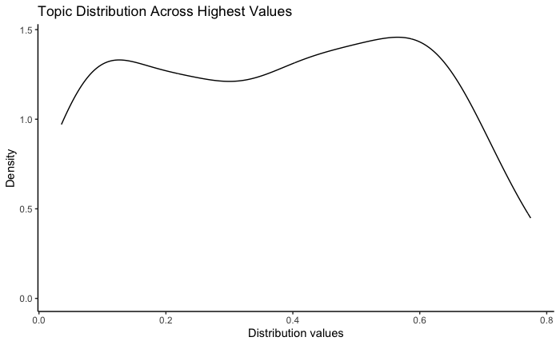

**Question 1 (BREAKOUT). Using the the data file “sample_news_1995-2017.csv”, Apply an LDA model with $k$ topics to the news sample dataframe (sample_news_1995-2017.csv). Assign the first $k$ based on your intuition and human judgement. View the terms associated. Are those topics substantively meaningful and coherent? Now, use the validation procedures we used to estimate the number of topics.**

### Apply supervised (seeded) LDA

Now, we will briefly cover one of two semi-supervised approaches to topic modeling. One of them is Structural Topic Modeling (STM), which is beyond the scope of what we can expound in a short intensive introductory TAD class. Interested students can visit the `stm` package and use the slides to gain initial insight into the `stm` approach.

The second approach is to “seed” an LDA model with terms known to represent a topic, which the model uses to identify related words and phrases. Here, the analyst not assigns $k$ but also *defines* the content within $k$.

Below, we use the dictionary terms from the policy agendas dictionary to “seed” the LDA model on the same dfm object regarding California legislative bills. A key difference between the LDA approach and the dictionary approach is that the LDA models “learns” which words are related to those seed words and uses that information to determine topics within documents.

As opposed to using all the possible seed words in the policy agendas dictionary, we take the first 10. Seeding with too many terms is not really seeding but pre-determining, and may risk overfitting the model.

Note that here we’re using the `seededlda` package quanteda recommends.

[figure not shown]

**Question 2. Why might we be getting such strange results?**

The first thing to do is ask ourselves if the seed terms sufficiently capture the topics we intend. Let’s be more intentional about our construction of the seed terminology and evaluate whether this improves topical output.

```r
terms(bills_lda_seed, 15)
```

[output not shown]

We have a ways to go, but an improvement on our first attempt. How do we determine whether unsupervised or supervised LDA is the right application? Like always, it depends on the research question and data generation process (e.g., what you know and don’t know about your data). A next step in this particular analysis might be comparing topic distributions (topics and terms) across documents based on either LDA output and evaluating meaning and coherence.

**Question 2 (BREAKOUT). Now apply the seeded LDA model to the news sample dataframe (sample_news_1995-2017.csv), either using the policy agendas dictionary or developing your own policy seed dictionary. After running the model, compare the two outputs and a sample of text. Does the unsupervised or supervised learning approach lead to more substantively meaningful and coherent topics?**